# Project 4: Explore and Summarize Data

by Djamshid Azizov

# Introduction.

In this project, we use R and apply exploratory data analysis techniques to explore relationships in one variable to multiple variables and to explore a selected data set for distributions, outliers, and anomalies. This data set is about red wine quality. It contains some chemical properties for each wine. At least 3 wine experts rated the quality of each wine, providing a rating between 0 (very bad) and 10 (very excellent). We want to determine which chemical properties influence the quality of red wines.

# Description of attributes:

1 - fixed acidity: most acids involved with wine or fixed or nonvolatile (do not evaporate readily) 2 - volatile acidity: the amount of acetic acid in wine, which at too high of levels can lead to an unpleasant, vinegar taste 3 - citric acid: found in small quantities, citric acid can add ‘freshness’ and flavor to wines 4 - residual sugar:the amount of sugar remaining after fermentation stops, it’s rare to find wines with less than 1gram/liter and wines with greater than 45 grams/liter are considered sweet 5 - chlorides: the amount of salt in the wine 6 - free sulfur dioxide: the free form of SO2 exists in equilibrium between molecular SO2 (as a dissolved gas) and bisulfite ion; it prevents microbial growth and the oxidation of wine 7 - total sulfur dioxide: amount of free and bound forms of S02; in low concentrations, SO2 is mostly undetectable in wine, but at free SO2 concentrations over 50 ppm, SO2 becomes evident in the nose and taste of wine 8 - density: the density of water is close to that of water depending on the percent alcohol and sugar content 9 - pH: describes how acidic or basic a wine is on a scale from 0 (very acidic) to 14 (very basic); most wines are between 3-4 on the pH scale 10 - sulphates: a wine additive which can contribute to sulfur dioxide gas (S02) levels, wich acts as an antimicrobial and antioxidant 11 - alcohol: the percent alcohol content of the wine. 12 - Output variable (based on sensory data): quality (score between 0 and 10)

First of all, let’s load all of the packages that we will be end up using in our analysis then load our data set wineQualityReds.csv

```
## 'data.frame':    1599 obs. of  13 variables:
##  $ X                   : int  1 2 3 4 5 6 7 8 9 10 ...
##  $ fixed.acidity       : num  7.4 7.8 7.8 11.2 7.4 7.4 7.9 7.3 7.8 7.5 ...
##  $ volatile.acidity    : num  0.7 0.88 0.76 0.28 0.7 0.66 0.6 0.65 0.58 0.5 ...
##  $ citric.acid         : num  0 0 0.04 0.56 0 0 0.06 0 0.02 0.36 ...
##  $ residual.sugar      : num  1.9 2.6 2.3 1.9 1.9 1.8 1.6 1.2 2 6.1 ...
##  $ chlorides           : num  0.076 0.098 0.092 0.075 0.076 0.075 0.069 0.065 0.073 0.071 ...
##  $ free.sulfur.dioxide : num  11 25 15 17 11 13 15 15 9 17 ...
##  $ total.sulfur.dioxide: num  34 67 54 60 34 40 59 21 18 102 ...
##  $ density             : num  0.998 0.997 0.997 0.998 0.998 ...
##  $ pH                  : num  3.51 3.2 3.26 3.16 3.51 3.51 3.3 3.39 3.36 3.35 ...
##  $ sulphates           : num  0.56 0.68 0.65 0.58 0.56 0.56 0.46 0.47 0.57 0.8 ...
##  $ alcohol             : num  9.4 9.8 9.8 9.8 9.4 9.4 9.4 10 9.5 10.5 ...
##  $ quality             : int  5 5 5 6 5 5 5 7 7 5 ...
```

After loading the data, lets take a global view. The types of variables and some examples of values:

```
##    Numbers fixed.acidity volatile.acidity citric.acid residual.sugar
## 1        1           7.4             0.70        0.00            1.9
## 2        2           7.8             0.88        0.00            2.6
## 3        3           7.8             0.76        0.04            2.3
## 4        4          11.2             0.28        0.56            1.9
## 5        5           7.4             0.70        0.00            1.9
## 6        6           7.4             0.66        0.00            1.8
## 7        7           7.9             0.60        0.06            1.6
## 8        8           7.3             0.65        0.00            1.2
## 9        9           7.8             0.58        0.02            2.0
## 10      10           7.5             0.50        0.36            6.1
##    chlorides free.sulfur.dioxide total.sulfur.dioxide density   pH
## 1      0.076                  11                   34  0.9978 3.51
## 2      0.098                  25                   67  0.9968 3.20
## 3      0.092                  15                   54  0.9970 3.26
```

[output cut: 18 more lines]

```
##  fixed.acidity   volatile.acidity  citric.acid    residual.sugar
##  Min.   : 4.60   Min.   :0.1200   Min.   :0.000   Min.   : 0.900
##  1st Qu.: 7.10   1st Qu.:0.3900   1st Qu.:0.090   1st Qu.: 1.900
##  Median : 7.90   Median :0.5200   Median :0.260   Median : 2.200
##  Mean   : 8.32   Mean   :0.5278   Mean   :0.271   Mean   : 2.539
##  3rd Qu.: 9.20   3rd Qu.:0.6400   3rd Qu.:0.420   3rd Qu.: 2.600
##  Max.   :15.90   Max.   :1.5800   Max.   :1.000   Max.   :15.500
##    chlorides       free.sulfur.dioxide total.sulfur.dioxide
##  Min.   :0.01200   Min.   : 1.00       Min.   :  6.00
##  1st Qu.:0.07000   1st Qu.: 7.00       1st Qu.: 22.00
##  Median :0.07900   Median :14.00       Median : 38.00
##  Mean   :0.08747   Mean   :15.87       Mean   : 46.47
##  3rd Qu.:0.09000   3rd Qu.:21.00       3rd Qu.: 62.00
##  Max.   :0.61100   Max.   :72.00       Max.   :289.00
##     density             pH          sulphates         alcohol
##  Min.   :0.9901   Min.   :2.740   Min.   :0.3300   Min.   : 8.40
##  1st Qu.:0.9956   1st Qu.:3.210   1st Qu.:0.5500   1st Qu.: 9.50
##  Median :0.9968   Median :3.310   Median :0.6200   Median :10.20
##  Mean   :0.9967   Mean   :3.311   Mean   :0.6581   Mean   :10.42
##  3rd Qu.:0.9978   3rd Qu.:3.400   3rd Qu.:0.7300   3rd Qu.:11.10
##  Max.   :1.0037   Max.   :4.010   Max.   :2.0000   Max.   :14.90
##     quality
##  Min.   :3.000
##  1st Qu.:5.000
##  Median :6.000
##  Mean   :5.636
##  3rd Qu.:6.000
##  Max.   :8.000
```

There are 1599 observations with 13 variables. All variables are numerical. Some of them seem to have outliers.

# UNNIVARIATE PLOTS SECTION

```
##  fixed.acidity   volatile.acidity  citric.acid    residual.sugar
##  Min.   : 4.60   Min.   :0.1200   Min.   :0.000   Min.   : 0.900
##  1st Qu.: 7.10   1st Qu.:0.3900   1st Qu.:0.090   1st Qu.: 1.900
##  Median : 7.90   Median :0.5200   Median :0.260   Median : 2.200
##  Mean   : 8.32   Mean   :0.5278   Mean   :0.271   Mean   : 2.539
##  3rd Qu.: 9.20   3rd Qu.:0.6400   3rd Qu.:0.420   3rd Qu.: 2.600
##  Max.   :15.90   Max.   :1.5800   Max.   :1.000   Max.   :15.500
##    chlorides       free.sulfur.dioxide total.sulfur.dioxide
##  Min.   :0.01200   Min.   : 1.00       Min.   :  6.00
##  1st Qu.:0.07000   1st Qu.: 7.00       1st Qu.: 22.00
##  Median :0.07900   Median :14.00       Median : 38.00
##  Mean   :0.08747   Mean   :15.87       Mean   : 46.47
##  3rd Qu.:0.09000   3rd Qu.:21.00       3rd Qu.: 62.00
##  Max.   :0.61100   Max.   :72.00       Max.   :289.00
##     density             pH          sulphates         alcohol
##  Min.   :0.9901   Min.   :2.740   Min.   :0.3300   Min.   : 8.40
##  1st Qu.:0.9956   1st Qu.:3.210   1st Qu.:0.5500   1st Qu.: 9.50
##  Median :0.9968   Median :3.310   Median :0.6200   Median :10.20
##  Mean   :0.9967   Mean   :3.311   Mean   :0.6581   Mean   :10.42
##  3rd Qu.:0.9978   3rd Qu.:3.400   3rd Qu.:0.7300   3rd Qu.:11.10
##  Max.   :1.0037   Max.   :4.010   Max.   :2.0000   Max.   :14.90
##     quality      quality.scale
##  Min.   :3.000   high   : 217
##  1st Qu.:5.000   average:1319
##  Median :6.000   low    :  63
##  Mean   :5.636
##  3rd Qu.:6.000
##  Max.   :8.000
```

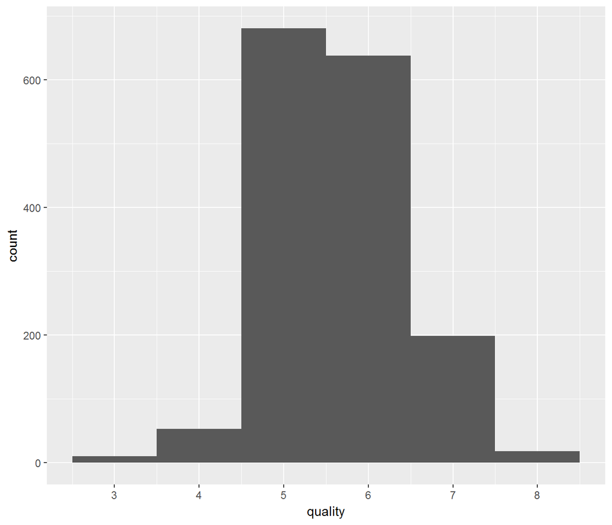

```
##    Min. 1st Qu.  Median    Mean 3rd Qu.    Max.
##   3.000   5.000   6.000   5.636   6.000   8.000
```

This is normal distribution histogram of Red wine quality. On this histogram the highest scale concentrated around 5 and 6.

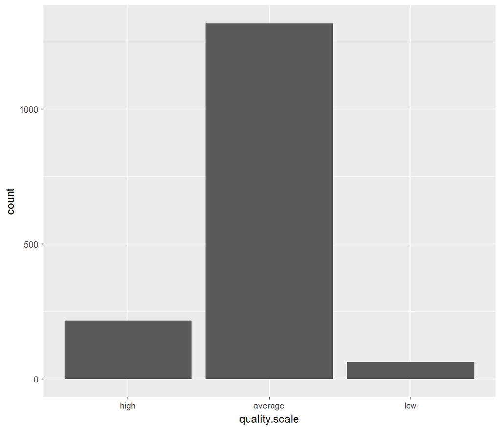

```
##    high average     low
##     217    1319      63
```

Here we can see that red wine quality concentrated in the avarege scale. So if we consider the average quality scale to be 5.5 in a 0 to 10 scale, we can see that our quality scale are beyond average.

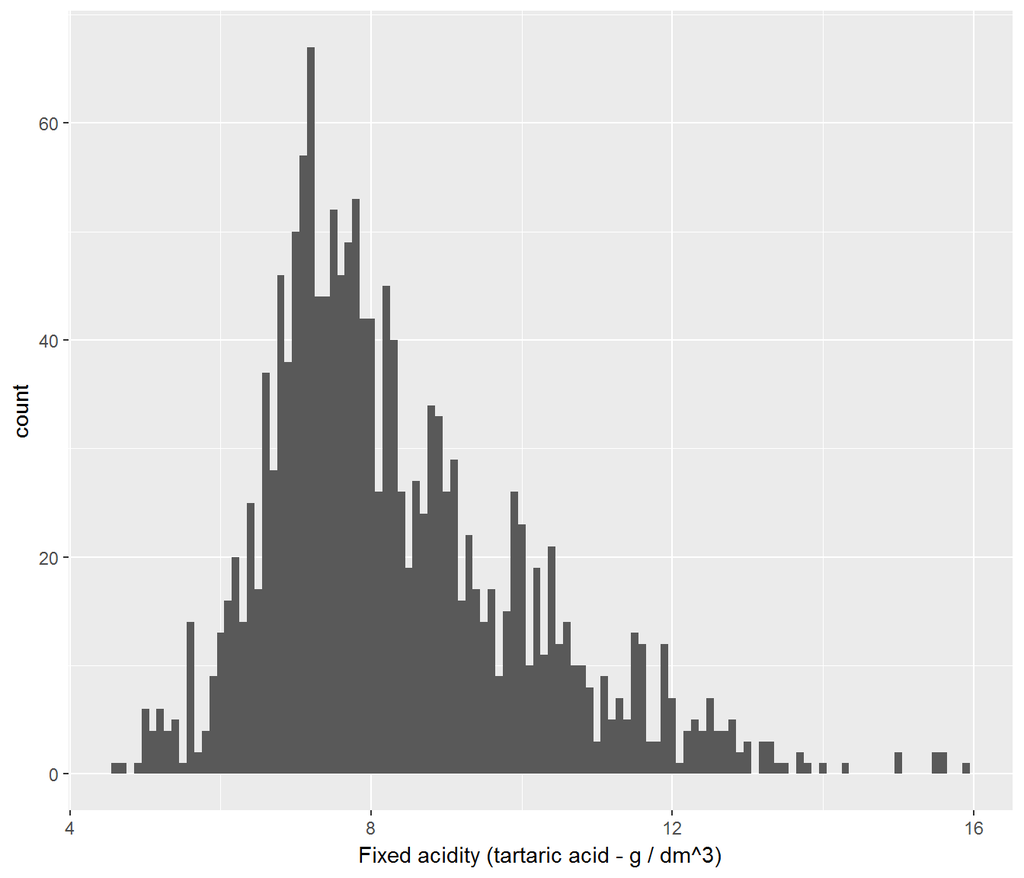

```
##    Min. 1st Qu.  Median    Mean 3rd Qu.    Max.
##    4.60    7.10    7.90    8.32    9.20   15.90
```

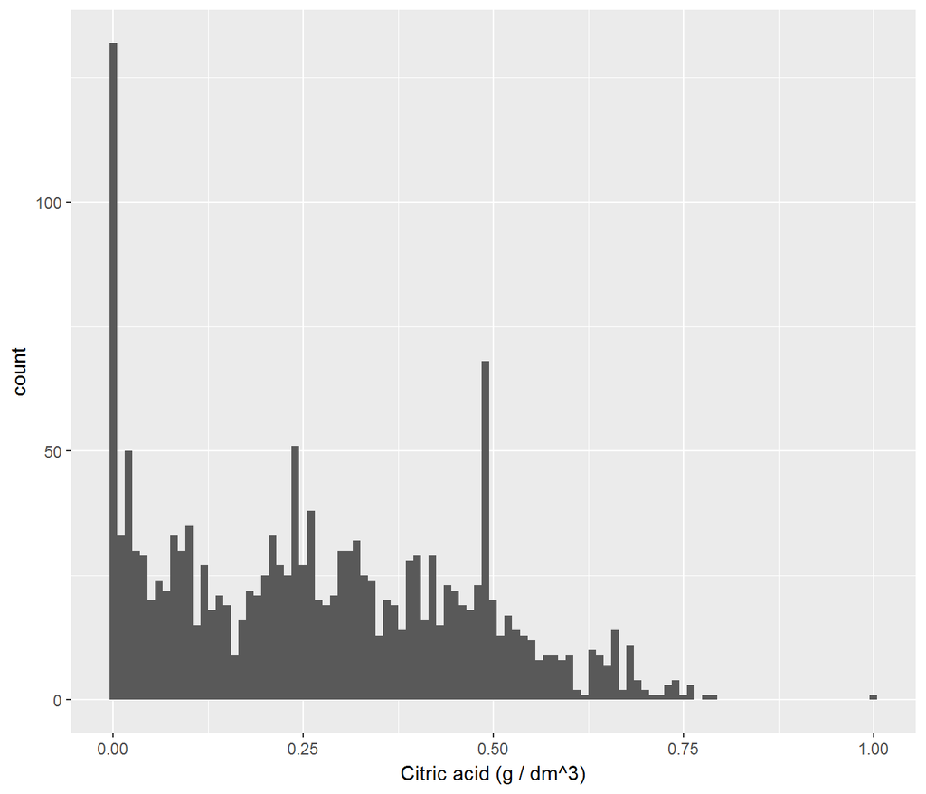

```
##    Min. 1st Qu.  Median    Mean 3rd Qu.    Max.
##   0.000   0.090   0.260   0.271   0.420   1.000
```

The distribution of citric acid is not normal. There is a value of 1, probably a measurement error: the biggest value around 0.8.

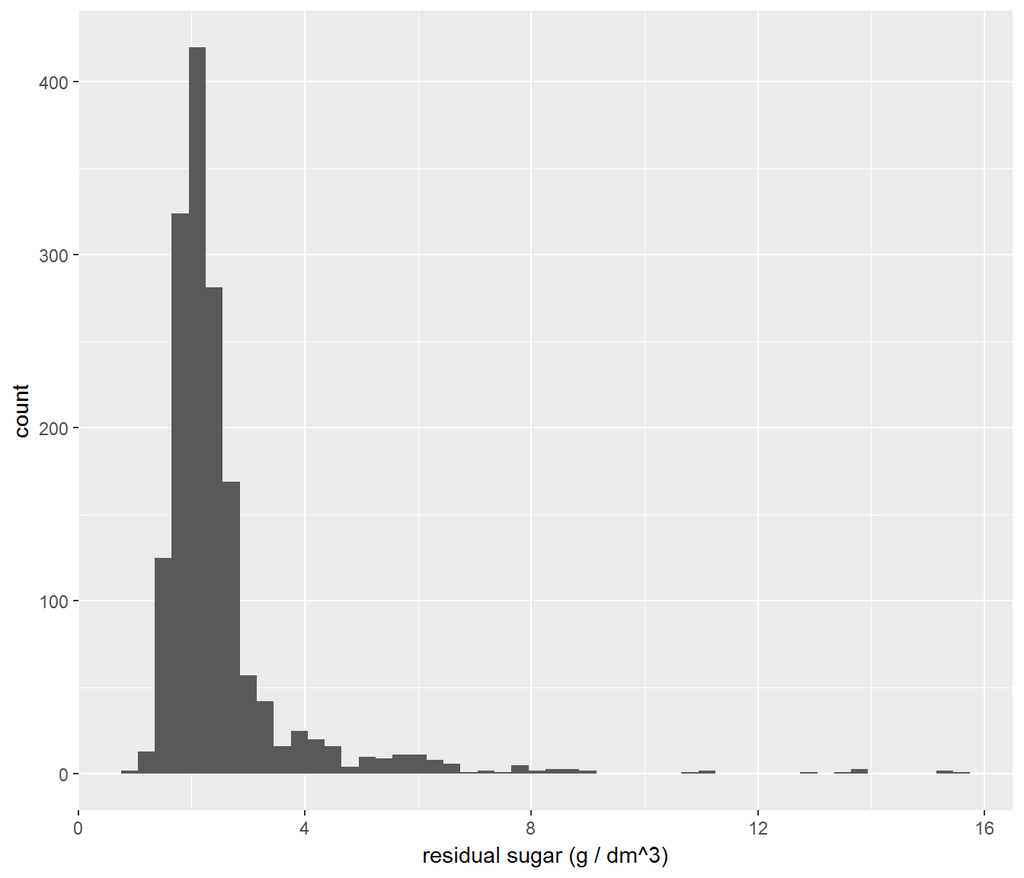

```
##    Min. 1st Qu.  Median    Mean 3rd Qu.    Max.
##   0.900   1.900   2.200   2.539   2.600  15.500
```

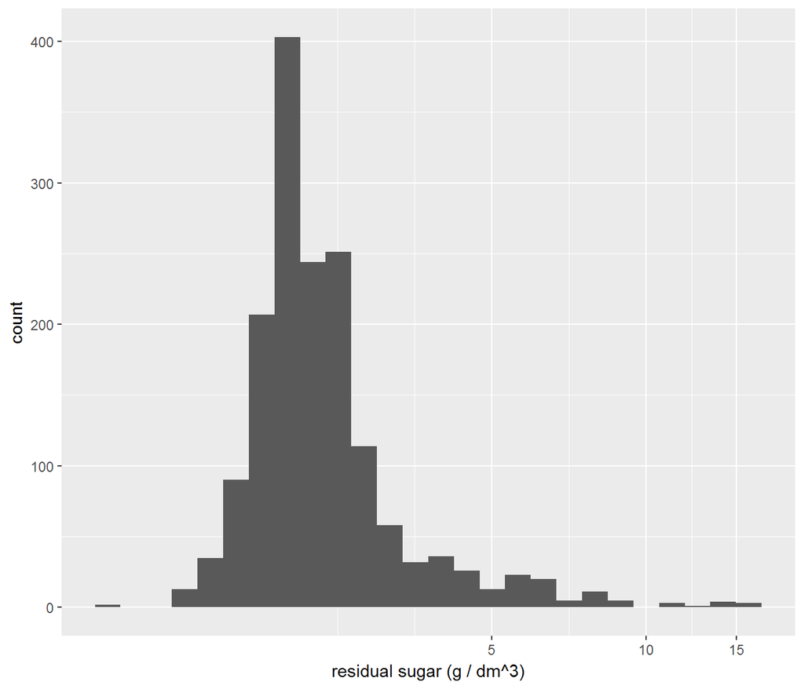

The distribution of residual sugar is right skewed, and concentrated around 2.2(the median) with some outliers along the higher ranges.

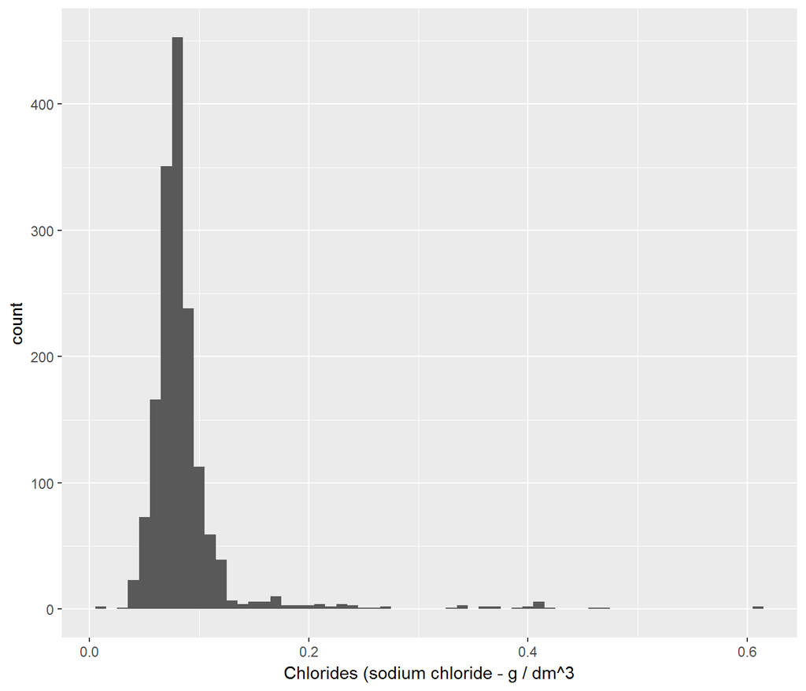

```
##    Min. 1st Qu.  Median    Mean 3rd Qu.    Max.
## 0.01200 0.07000 0.07900 0.08747 0.09000 0.61100
```

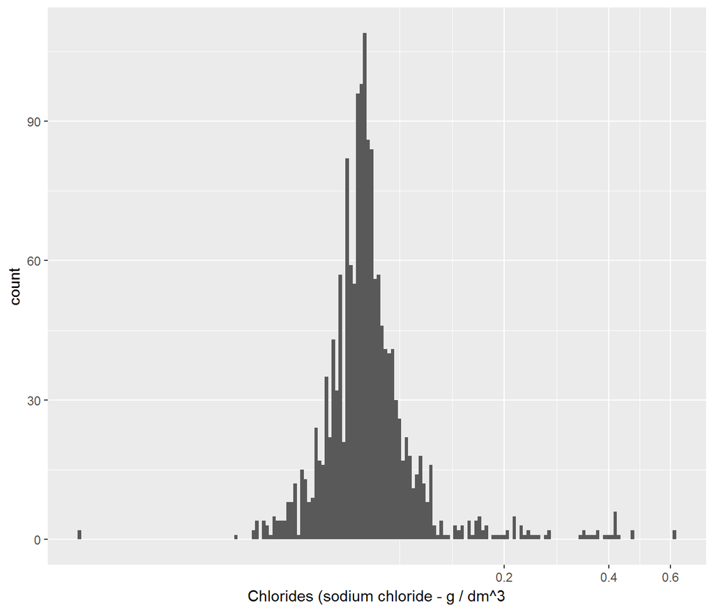

The distribution of chlorides is right skewed, and concentrated around 0.08. The plot has some outliers.

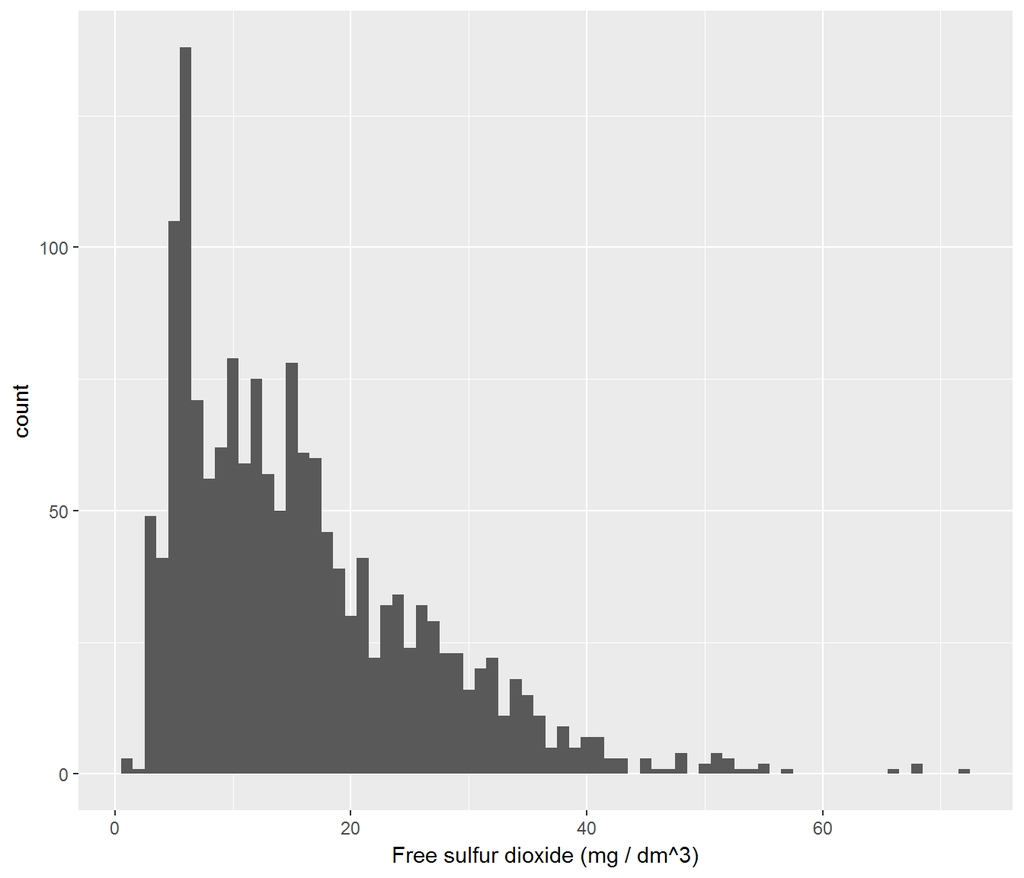

```
##    Min. 1st Qu.  Median    Mean 3rd Qu.    Max.
##    1.00    7.00   14.00   15.87   21.00   72.00
```

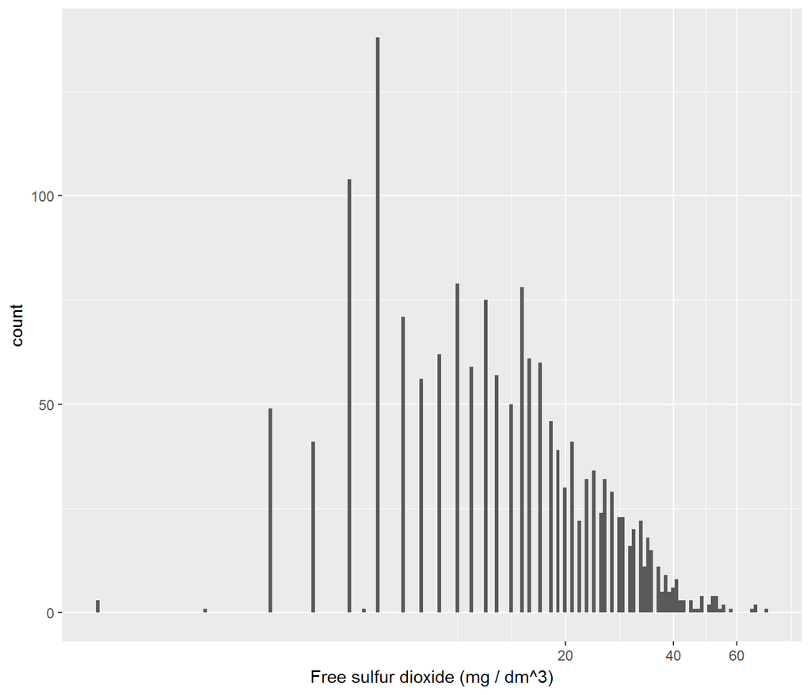

The distribution of free sulfur dioxide is right skewed and concentrated around 14. The peak at around 7 and a long tailed distribution with few wines over 60.

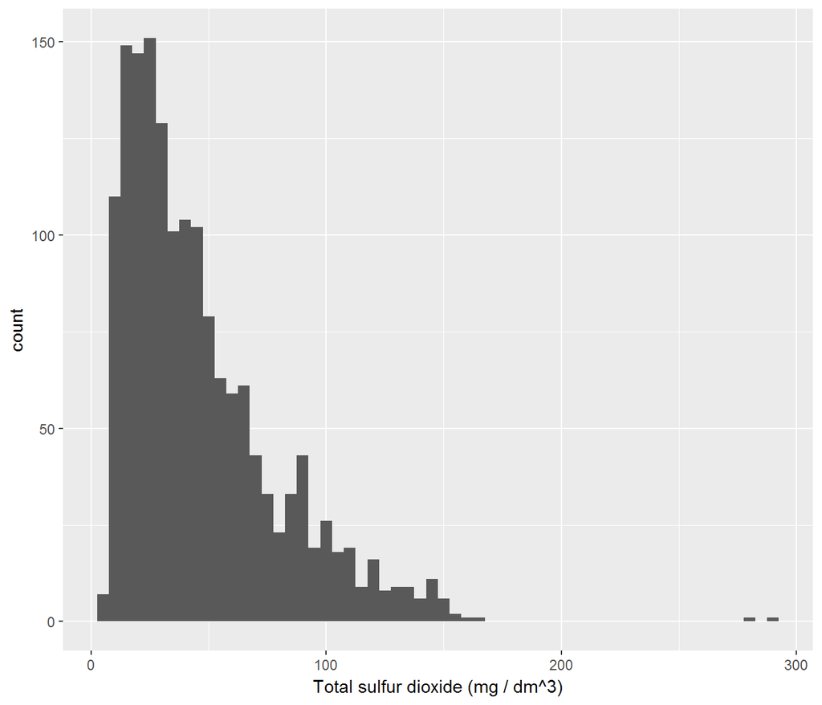

```
##    Min. 1st Qu.  Median    Mean 3rd Qu.    Max.
##    6.00   22.00   38.00   46.47   62.00  289.00
```

The distribution of Total free sulfur dioxide is consentrated around 38. It looks like with last distribution.

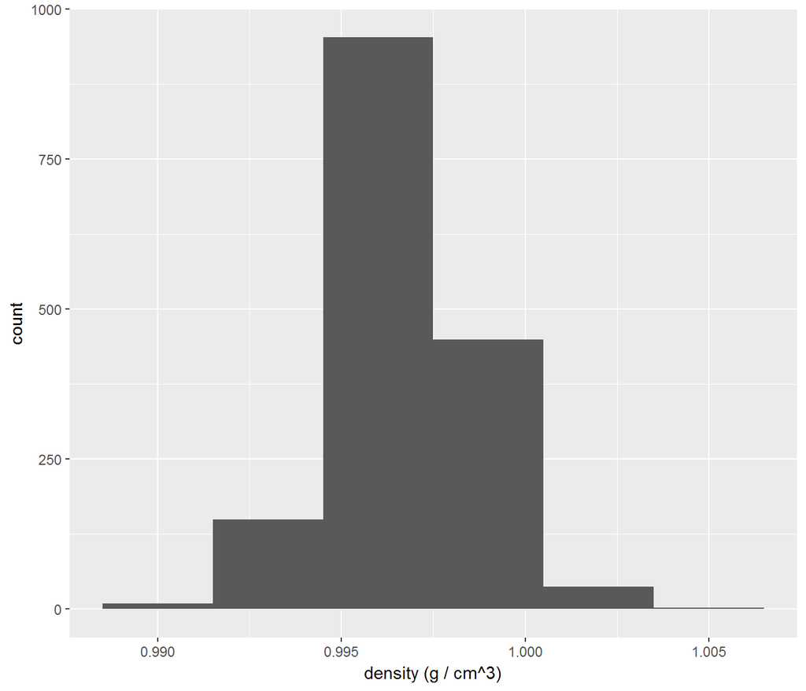

```
##    Min. 1st Qu.  Median    Mean 3rd Qu.    Max.
##  0.9901  0.9956  0.9968  0.9967  0.9978  1.0037
```

The distribution for density has a very normal appearence. It concentrated around 0.9967

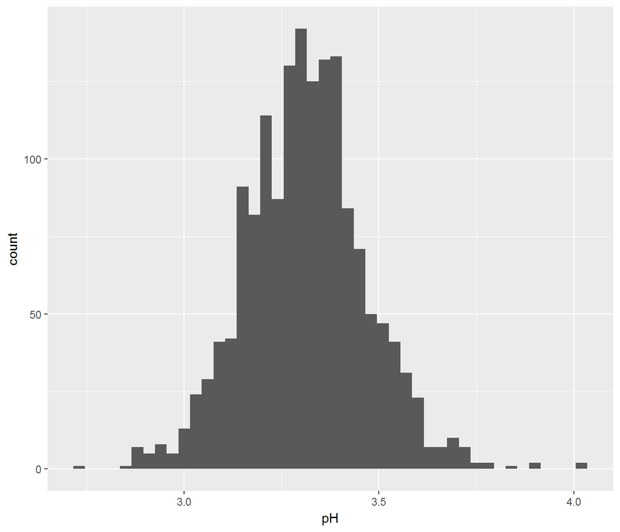

```
##    Min. 1st Qu.  Median    Mean 3rd Qu.    Max.
##   2.740   3.210   3.310   3.311   3.400   4.010
```

This is normal distribution. PH concentrated around 3.310

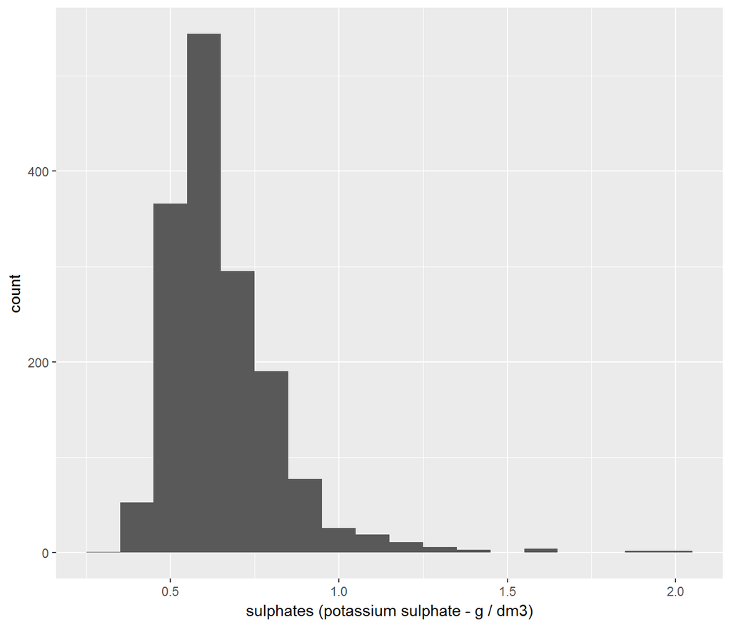

```
##    Min. 1st Qu.  Median    Mean 3rd Qu.    Max.
##  0.3300  0.5500  0.6200  0.6581  0.7300  2.0000
```

For sulphates we see a distribution similar to the ones of residual.sugar and chlorides.

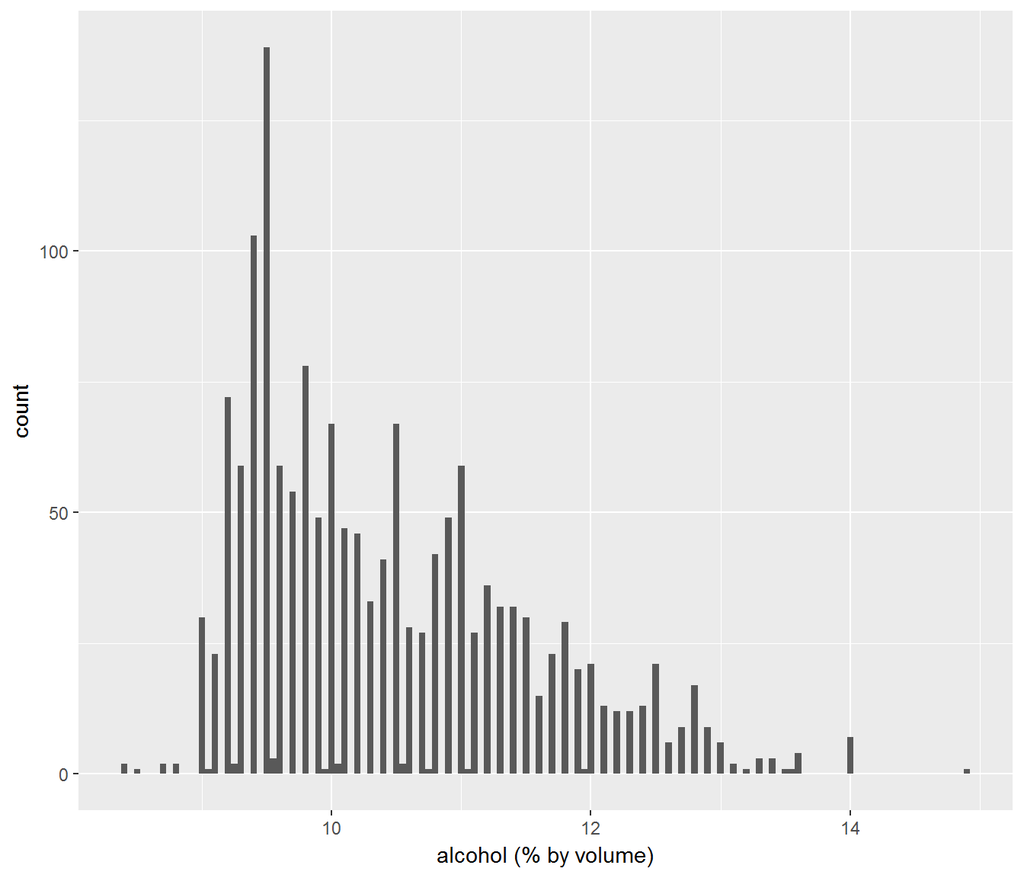

```
##    Min. 1st Qu.  Median    Mean 3rd Qu.    Max.
##    8.40    9.50   10.20   10.42   11.10   14.90
```

Influential variables. Let have a look at how correlated our different variables with quality.

```
##                             [,1]
## fixed.acidity         0.12405165
## volatile.acidity     -0.39055778
## citric.acid           0.22637251
## residual.sugar        0.01373164
## chlorides            -0.12890656
## free.sulfur.dioxide  -0.05065606
## total.sulfur.dioxide -0.18510029
## density              -0.17491923
## pH                   -0.05773139
## sulphates             0.25139708
## alcohol               0.47616632
```

# UNIVARIABLE ANALYSIS

### What is the structure of your dataset?

# Answer:

There are 1599 observation of wines in the dataset with 12 features (variables) . There is one categorical variable (quality) and the others are numerical variables that indicate wine physical and chemical properties of the wine. Other observations: The median quality is 6, which in the given scale (1-10). The high wine quality in the sample has a scale of 8, and the low wine quality has a scale of 3.

### What is/are the main feature(s) of interest in your dataset?

# Answer:

The main feature in the data is quality. I’d like to determine which features determine the quality of wines.

### What other features in the dataset do you think will help support your investigation into your feature(s) of interest?

# Answer:

Volatile acidity, chlorides, residual sugar and alcohol might have median or small impact on the quality of wine.

### Did you create any new variables from existing variables in the dataset?

# Answer:

I created a new variable called “quality.scale” which is categorically divided into “low”, “average”, and “high”. This grouping method will help us determine the difference among each group more easily.

### Of the features you investigated, were there any unusual distributions?

# Did you perform any operations on the data to tidy, adjust, or change the form of the data? If so, why did you do this?

# Answer:

Most of the features have outliers that are far beyond the 3rd quartile in their distributions. Maybe this is one of the reasons why most of them are right skewed. Having visualized citric acid, free sulfur dioxide and alcohol data, I observed some unusual distributions, so I guess this fact may have some correlation with the quality of red wine. Since the data is clean, I did not perform any cleaning process or modification of the data. There’s no data cleaning or wrangling involved in this data set.

# BIVARIATE PLOT SECTION

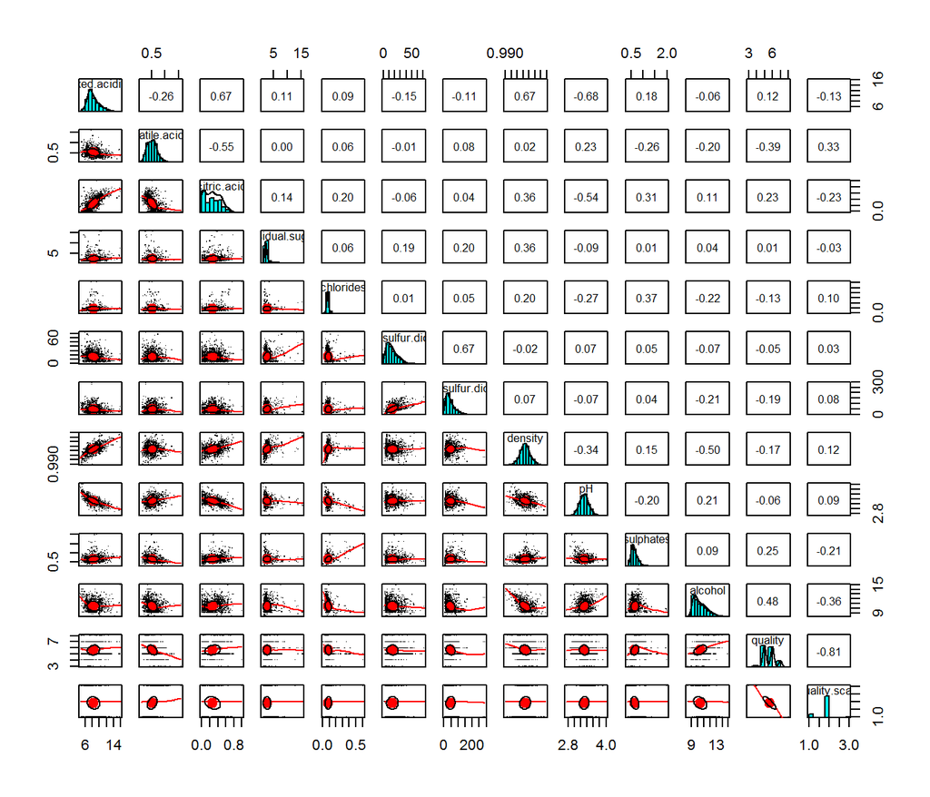

```
##                      fixed.acidity volatile.acidity citric.acid
## fixed.acidity           1.00000000     -0.256130895  0.67170343
## volatile.acidity       -0.25613089      1.000000000 -0.55249568
## citric.acid             0.67170343     -0.552495685  1.00000000
## residual.sugar          0.11477672      0.001917882  0.14357716
## chlorides               0.09370519      0.061297772  0.20382291
## free.sulfur.dioxide    -0.15379419     -0.010503827 -0.06097813
## total.sulfur.dioxide   -0.11318144      0.076470005  0.03553302
## density                 0.66804729      0.022026232  0.36494718
## pH                     -0.68297819      0.234937294 -0.54190414
## sulphates               0.18300566     -0.260986685  0.31277004
## alcohol                -0.06166827     -0.202288027  0.10990325
## quality                 0.12405165     -0.390557780  0.22637251
##                      residual.sugar    chlorides free.sulfur.dioxide
## fixed.acidity           0.114776724  0.093705186        -0.153794193
## volatile.acidity        0.001917882  0.061297772        -0.010503827
## citric.acid             0.143577162  0.203822914        -0.060978129
## residual.sugar          1.000000000  0.055609535         0.187048995
## chlorides               0.055609535  1.000000000         0.005562147
## free.sulfur.dioxide     0.187048995  0.005562147         1.000000000
## total.sulfur.dioxide    0.203027882  0.047400468         0.667666450
## density                 0.355283371  0.200632327        -0.021945831
## pH                     -0.085652422 -0.265026131         0.070377499
## sulphates               0.005527121  0.371260481         0.051657572
## alcohol                 0.042075437 -0.221140545        -0.069408354
## quality                 0.013731637 -0.128906560        -0.050656057
##                      total.sulfur.dioxide     density          pH
## fixed.acidity                 -0.11318144  0.66804729 -0.68297819
## volatile.acidity               0.07647000  0.02202623  0.23493729
## citric.acid                    0.03553302  0.36494718 -0.54190414
## residual.sugar                 0.20302788  0.35528337 -0.08565242
## chlorides                      0.04740047  0.20063233 -0.26502613
## free.sulfur.dioxide            0.66766645 -0.02194583  0.07037750
## total.sulfur.dioxide           1.00000000  0.07126948 -0.06649456
## density                        0.07126948  1.00000000 -0.34169933
## pH                            -0.06649456 -0.34169933  1.00000000
## sulphates                      0.04294684  0.14850641 -0.19664760
## alcohol                       -0.20565394 -0.49617977  0.20563251
## quality                       -0.18510029 -0.17491923 -0.05773139
##                         sulphates     alcohol     quality
## fixed.acidity         0.183005664 -0.06166827  0.12405165
## volatile.acidity     -0.260986685 -0.20228803 -0.39055778
## citric.acid           0.312770044  0.10990325  0.22637251
## residual.sugar        0.005527121  0.04207544  0.01373164
## chlorides             0.371260481 -0.22114054 -0.12890656
## free.sulfur.dioxide   0.051657572 -0.06940835 -0.05065606
## total.sulfur.dioxide  0.042946836 -0.20565394 -0.18510029
## density               0.148506412 -0.49617977 -0.17491923
## pH                   -0.196647602  0.20563251 -0.05773139
## sulphates             1.000000000  0.09359475  0.25139708
## alcohol               0.093594750  1.00000000  0.47616632
## quality               0.251397079  0.47616632  1.00000000
```

From a subset of the data, the feature Alcohol has high negative correlation with density (-0.50). This is fact as alcohol has less dense than water. Volatile.acidity has a positive correlation with pH(0.23). This is unexpected as pH is a direct measure of acidity. Free.sulfur.dioxide and total.sulfur.dioxide are highly correlated as expected(0.67). Density has a very strong correlation with fixed.acidity(0.67). Same correlation coefficient has Citric.acid with fixed.acidity(0.67).

Lets examine these variables with some boxplots by quality scale:

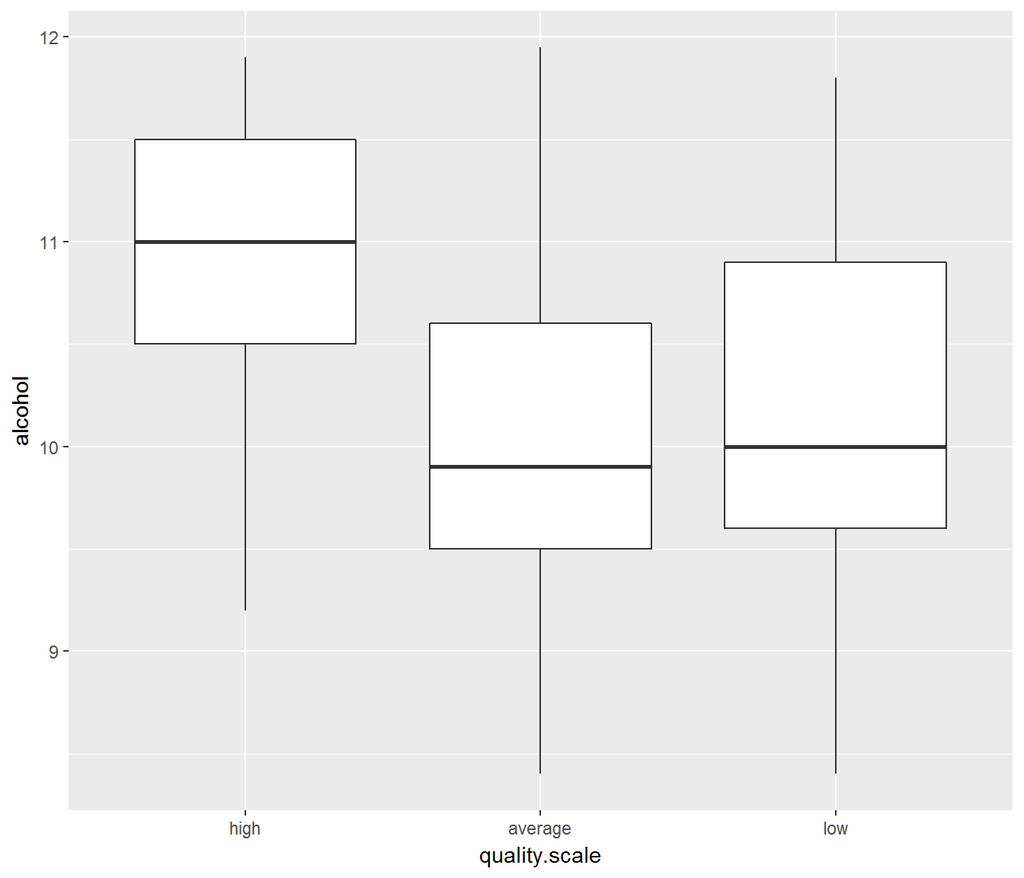

```
##
##  Pearson's product-moment correlation
##
## data:  RW$quality and RW$alcohol
## t = 21.639, df = 1597, p-value < 2.2e-16
## alternative hypothesis: true correlation is not equal to 0
## 95 percent confidence interval:
##  0.4373540 0.5132081
## sample estimates:
##       cor
## 0.4761663
```

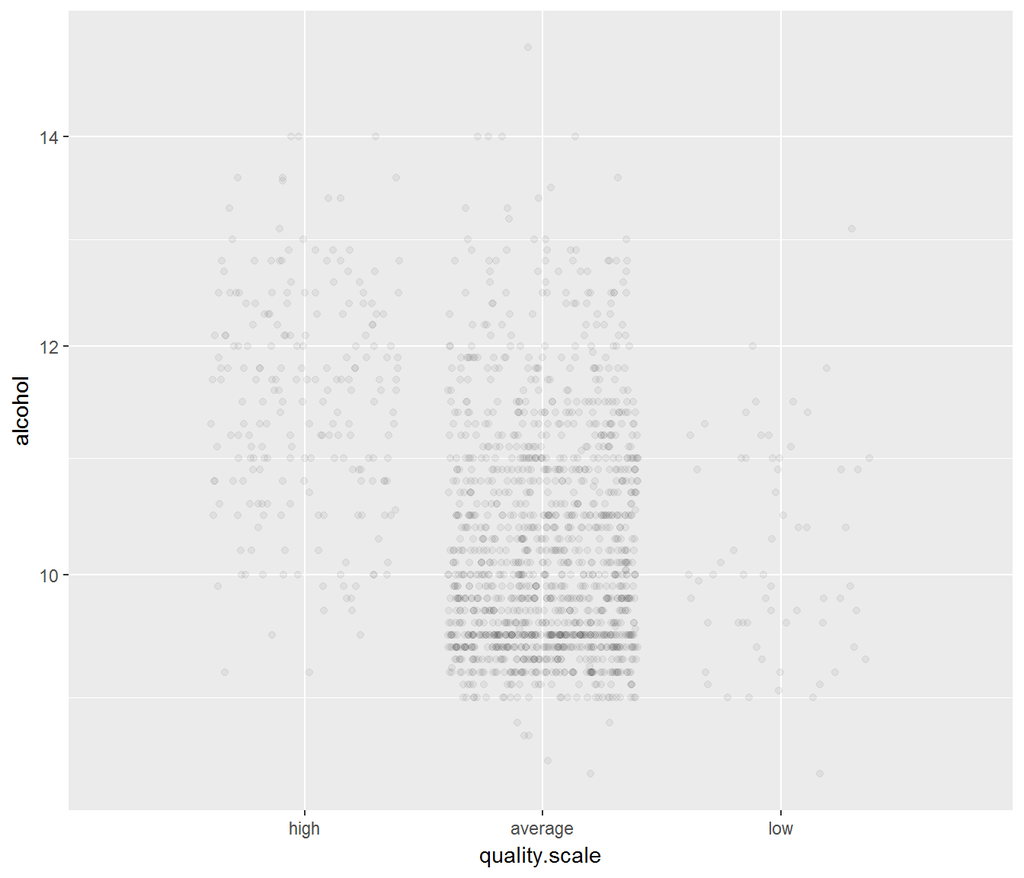

With the correlation coefficient of 0.476, the boxplot shows a positive relationship between alcohol and quality scale. Average quality and low quality wines have their percent alcohol contents concentrated around 10 whereas high quality wines have their percent alcohol contents concentrated around 11-13.

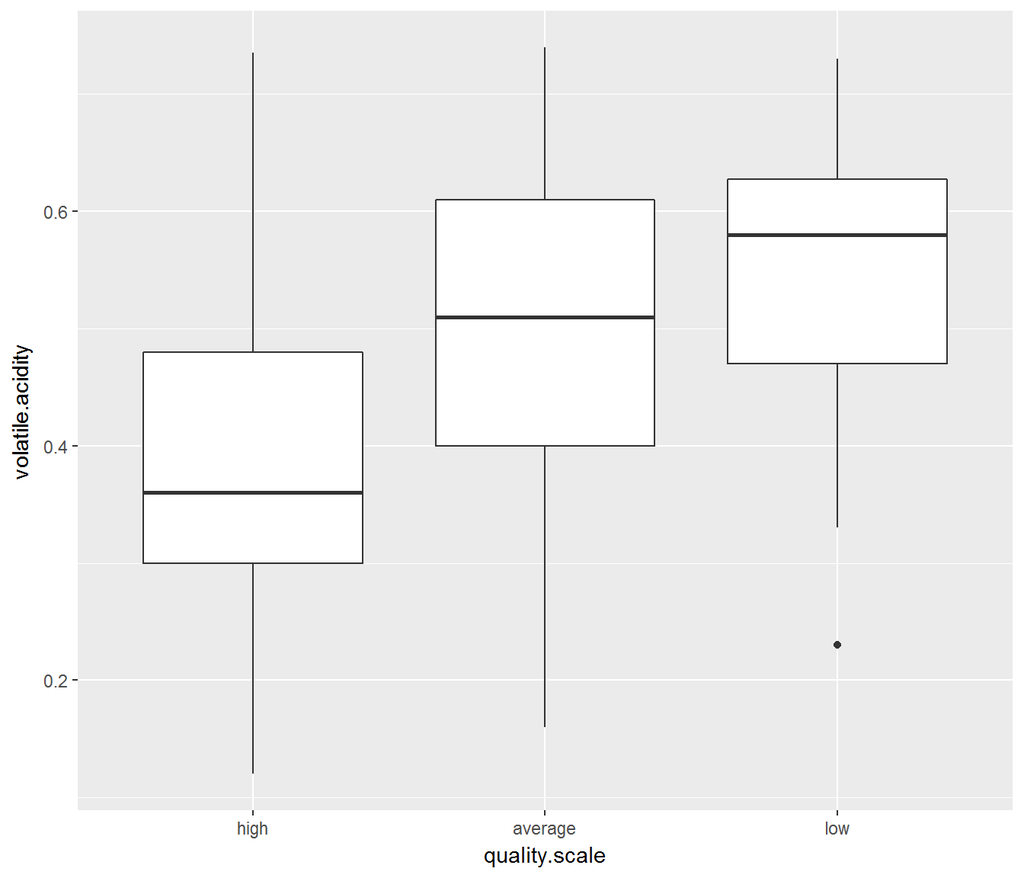

```
##
##  Pearson's product-moment correlation
##
## data:  RW$quality and RW$volatile.acidity
## t = -16.954, df = 1597, p-value < 2.2e-16
## alternative hypothesis: true correlation is not equal to 0
## 95 percent confidence interval:
##  -0.4313210 -0.3482032
## sample estimates:
##        cor
## -0.3905578
```

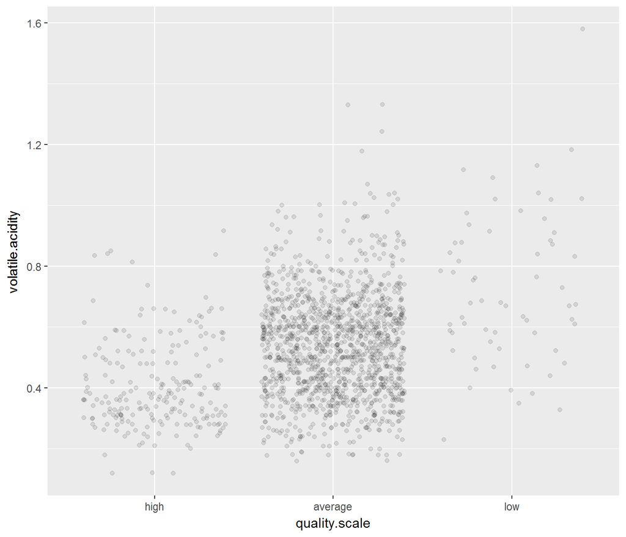

There is a negative correlation between quality and volatile acidity. volatile.acidity seems to be an unwanted feature is wines. Quality seems to go down when volatile.acidity goes up.

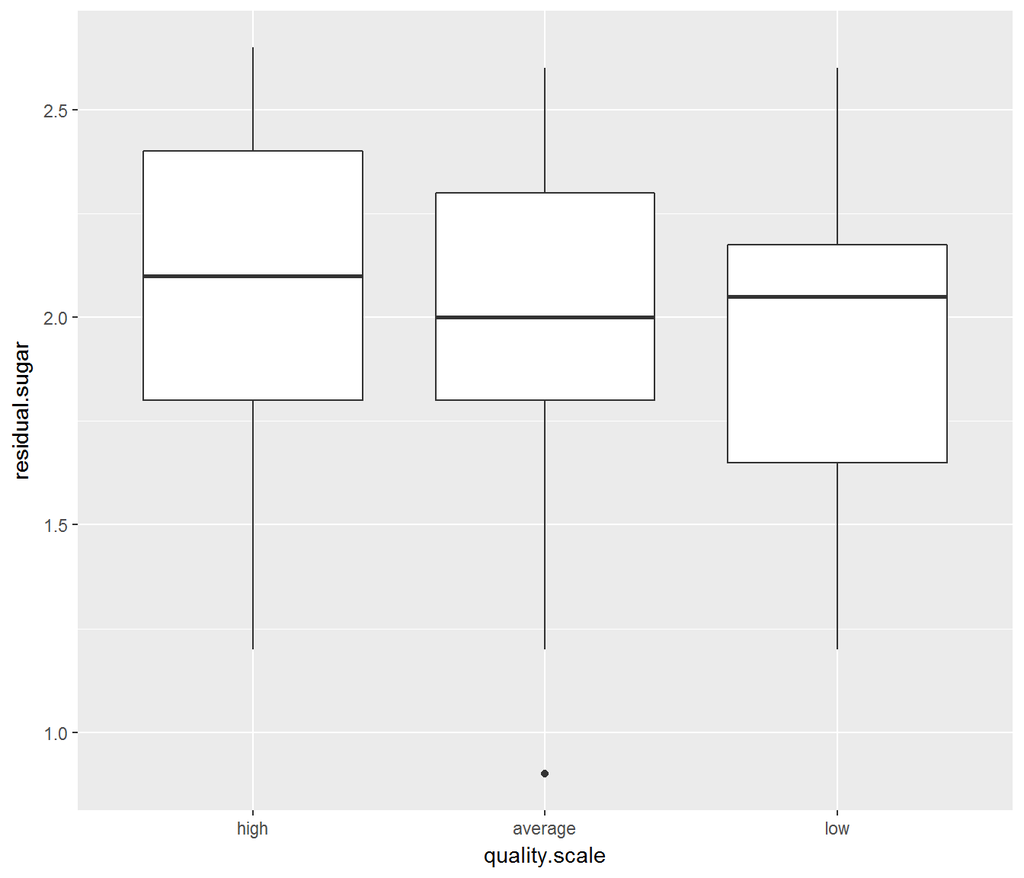

```
##
##  Pearson's product-moment correlation
##
## data:  RW$quality and RW$residual.sugar
## t = 0.5488, df = 1597, p-value = 0.5832
## alternative hypothesis: true correlation is not equal to 0
## 95 percent confidence interval:
##  -0.03531327  0.06271056
## sample estimates:
##        cor
## 0.01373164
```

The correlation coefficient between residual sugar and quality is 0.014. As we would expect residual sugar seems to have a little bit or almost no effect on quality of wine.

Now let’s scatterplot the following variable pairs residual sugar vs alcohol, alcohol vs density, sugar vs density

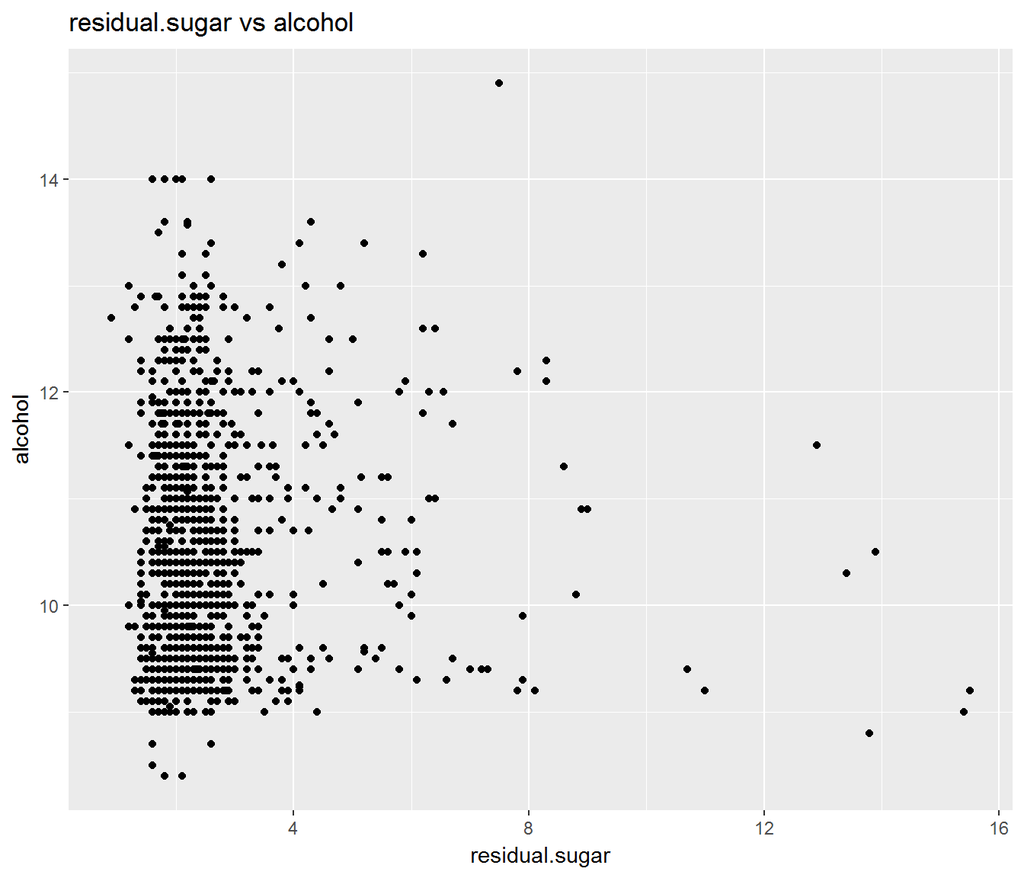

```
##
##  Pearson's product-moment correlation
##
## data:  RW$residual.sugar and RW$alcohol
## t = 1.6829, df = 1597, p-value = 0.09258
## alternative hypothesis: true correlation is not equal to 0
## 95 percent confidence interval:
##  -0.006960058  0.090909069
## sample estimates:
##        cor
## 0.04207544
```

The correlation coefficient between residual sugar and alcohol is too weak. It is 0.042.

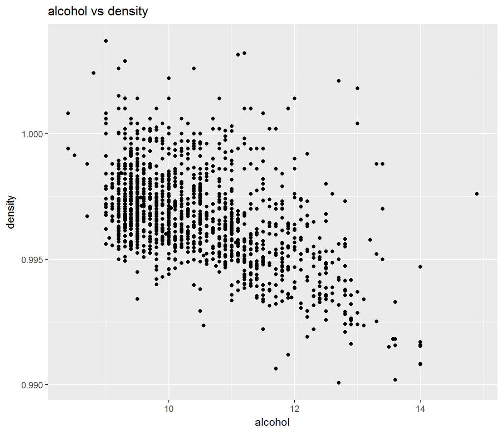

```
##
##  Pearson's product-moment correlation
##
## data:  RW$alcohol and RW$density
## t = -22.838, df = 1597, p-value < 2.2e-16
## alternative hypothesis: true correlation is not equal to 0
## 95 percent confidence interval:
##  -0.5322547 -0.4583061
## sample estimates:
##        cor
## -0.4961798
```

The correlation coefficient between alcohol and density is pretty strong negative. it is -0.49

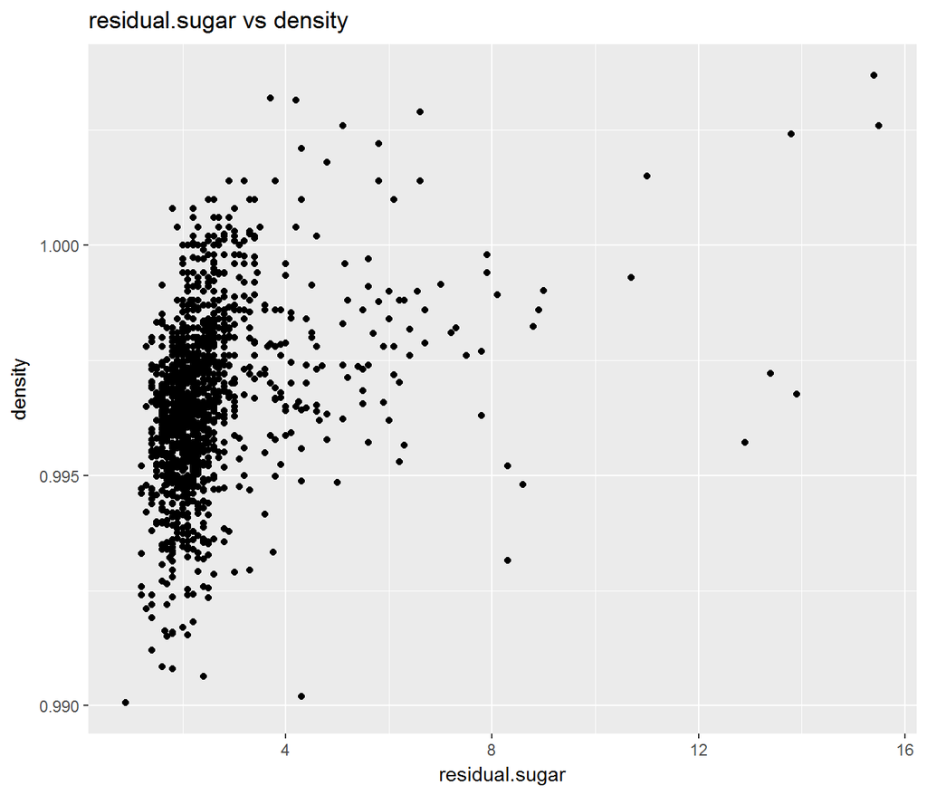

```
##
##  Pearson's product-moment correlation
##
## data:  RW$residual.sugar and RW$density
## t = 15.189, df = 1597, p-value < 2.2e-16
## alternative hypothesis: true correlation is not equal to 0
## 95 percent confidence interval:
##  0.3116908 0.3973835
## sample estimates:
##       cor
## 0.3552834
```

The correlation coefficient between residual sugar and density look stronger.

# BIVARIATE ANALYSIS

### Talk about some of the relationships you observed in this part of the investigation.

# How did the feature(s) of interest vary with other features in the dataset?

# Answer:

I observed a negative relationships between quality scale and volatile acidity, and positive correlation between quality scale and alcohol. Probably people value stronger wines as high quality, than wines with low percent alcohol. High volatile acidity is also perceived to be undesirable because it impacts the taste of wines.

### Did you observe any interesting relationships between the other features #(not the main feature(s) of interest)?

# Answer:

### What was the strongest relationship you found?

# Answer:

Of the above observation, I can say that quality of wine is positively and strongly correlated with alcohol, and it is also negatively correlated with volatile acidity. I assume that alcohol and volatile acidity could be used in a model to predict the quality of wine.

# MULTIVARIATE ANALYSIS

Lets try using multivariate plots to answer some questions that mentioned above and to look for other relationships in the data.

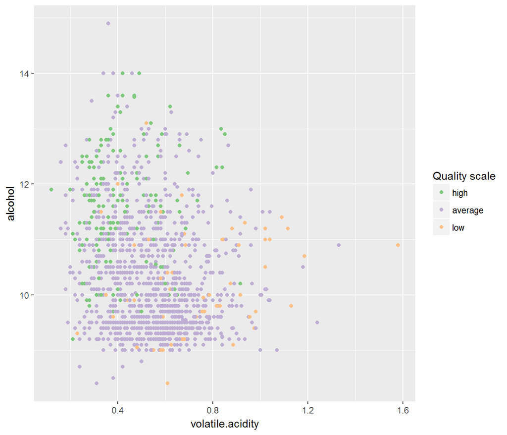

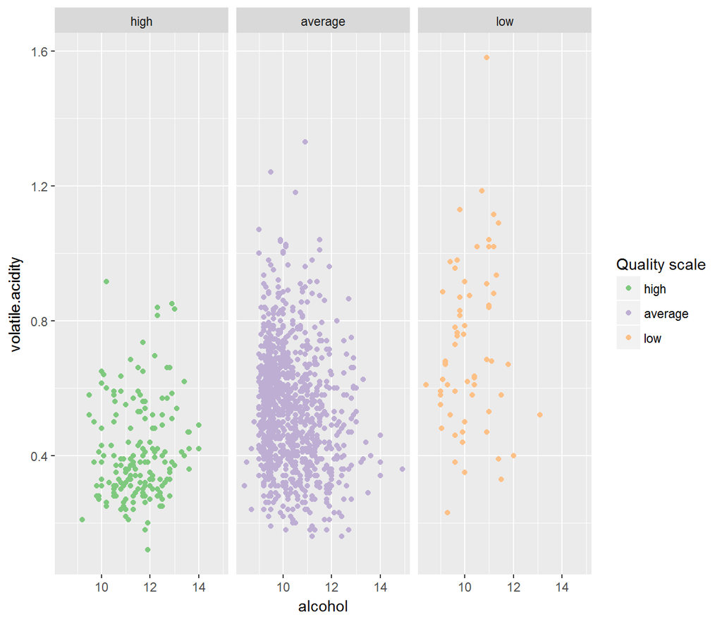

It seems having less acetic acid on higher concentration of alcohol is produced better wines

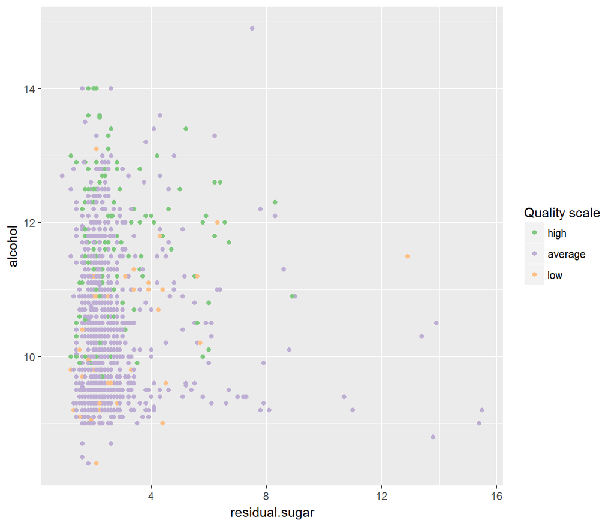

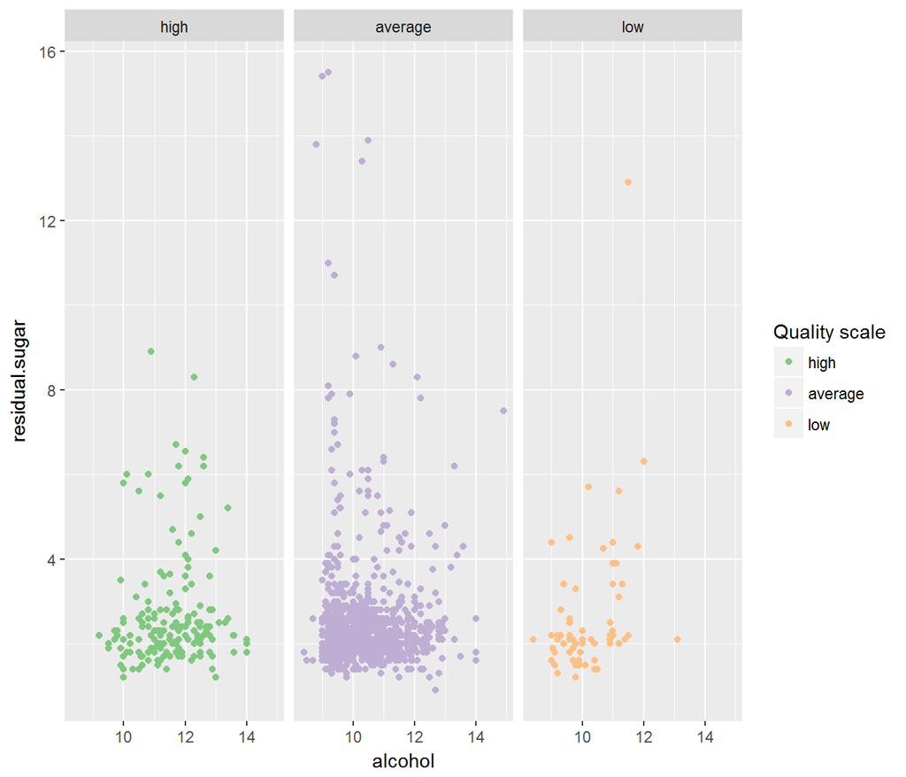

Residual sugar has very little impact on wine quality.

Let’s investigate the relationship between the deferent acids and quality.

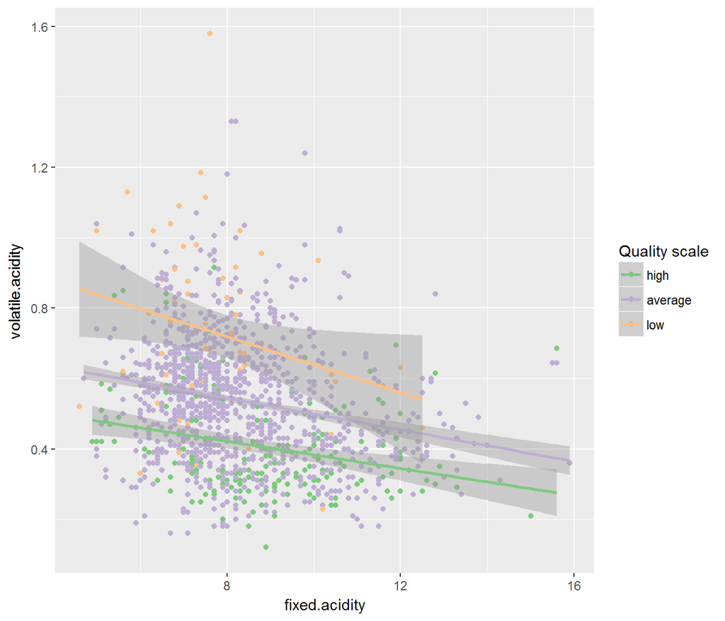

Almost no variance in the y axis compared to the x axis. Lets try the other acids.

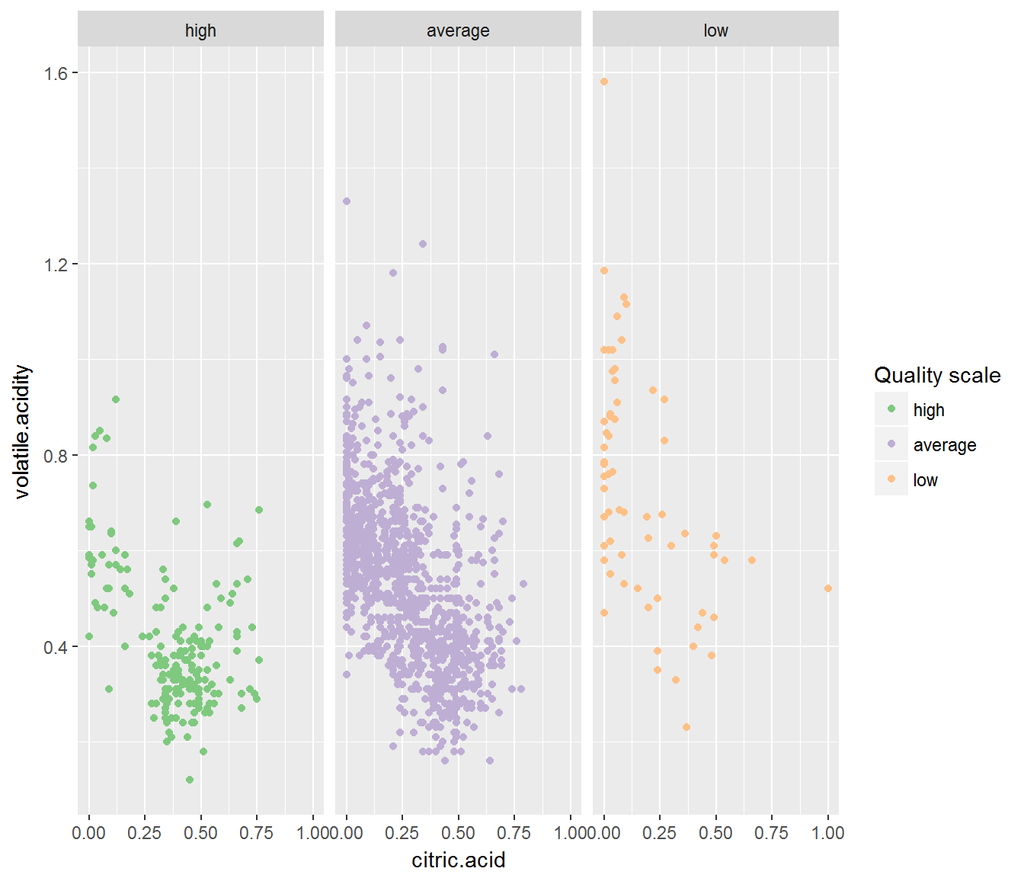

High citric acid and low acetic acid seems like a good combination.

And finally, lets create linear models using our above features. The first model includes only “alcohol” as predictor. Then next model add “volatile.acidity”. Model 3 is “fixed acidity”, and the last model is “citric.acid”.

```
##
## Calls:
## m1: lm(formula = I(quality ~ alcohol), data = RW)
## m2: lm(formula = quality ~ alcohol + volatile.acidity, data = RW)
## m3: lm(formula = quality ~ alcohol + volatile.acidity + fixed.acidity,
##     data = RW)
## m4: lm(formula = quality ~ alcohol + volatile.acidity + fixed.acidity +
##     citric.acid, data = RW)
##
## ================================================================
##                        m1         m2         m3         m4
## ----------------------------------------------------------------
##   (Intercept)        1.875***   3.095***   2.674***   2.622***
##                     (0.175)    (0.184)    (0.218)    (0.219)
##   alcohol            0.361***   0.314***   0.321***   0.325***
##                     (0.017)    (0.016)    (0.016)    (0.016)
##   volatile.acidity             -1.384***  -1.286***  -1.420***
##                                (0.095)    (0.099)    (0.115)
##   fixed.acidity                            0.036***   0.056***
##                                           (0.010)    (0.013)
##   citric.acid                                        -0.314*
##                                                      (0.137)
## ----------------------------------------------------------------
##   R-squared              0.2        0.3        0.3        0.3
##   adj. R-squared         0.2        0.3        0.3        0.3
##   sigma                  0.7        0.7        0.7        0.7
##   F                    468.3      370.4      253.1      191.6
##   p                      0.0        0.0        0.0        0.0
##   Log-likelihood     -1721.1    -1621.8    -1615.4    -1612.7
##   Deviance             805.9      711.8      706.1      703.8
##   AIC                 3448.1     3251.6     3240.8     3237.5
##   BIC                 3464.2     3273.1     3267.6     3269.7
##   N                   1599       1599       1599       1599
## ================================================================
```

Quality has a weak positive relationship with alcohol, and weak negative relationship with volatile acid. The R squared values are low; this result indicates that the regression models have significant variable but explains little of the variability. The quality of wine does not solely depends on volatile acidity and alcohol but also other features. Therefore, it is hard to build a predictive model that can accurately predict the quality of wine.

# MULTIVARIATE ANALYSIS

### Talk about some of the relationships you observed in this part of the investigation. Were there features that strengthened each other in terms of looking at your feature(s) of interest?

# Answer:

### Were there any interesting or surprising interactions between features?

# Answer:

Residual sugar, supposed to play an important part in wine taste, actually has very little impact on wine quality.

### OPTIONAL: Did you create any models with your dataset? Discuss the strengths and limitations of your model.

# Answer:

## FINAL PLOT AND SUMMARY

### PLOT ONE

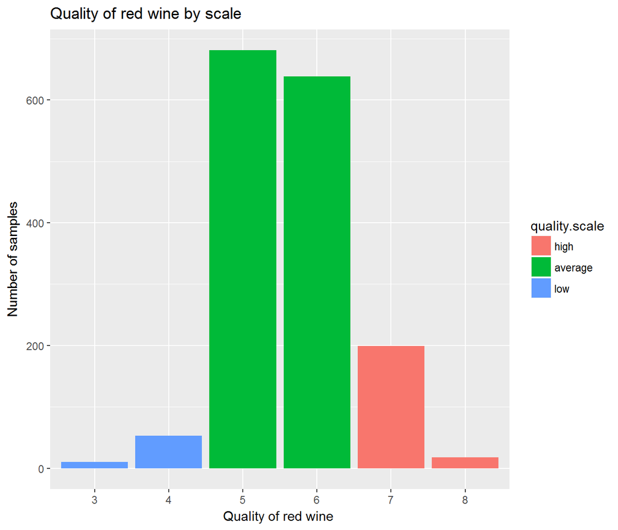

### DESCRIPTION ONE.

The distribution of wine quality is normal. On this histogram the highest scale concentrated around 5 and 6. Interesting for me to know why quality of scales start with lowest scale 3,4 and end with highest scales 7,8. Why is quality scale not measured by such numbers 1,2 and 9,10.

### PLOT TWO

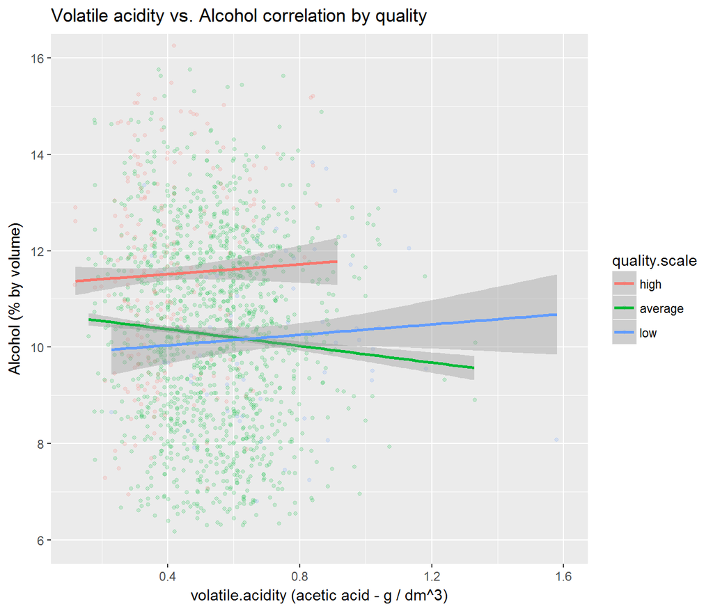

```
##
##  Pearson's product-moment correlation
##
## data:  RW$volatile.acidity and RW$alcohol
## t = -8.2546, df = 1597, p-value = 3.155e-16
## alternative hypothesis: true correlation is not equal to 0
## 95 percent confidence interval:
##  -0.2488416 -0.1548020
## sample estimates:
##       cor
## -0.202288
```